# Lab1

Colter King

2020-08-31

# Tasks

## Task 1

Find the working directory

```r
getwd()
```

```
## [1] "C:/Users/Colter King/Documents/RProject/MATH4753KingProj1/Lab1"
```

## Task 2

Read in the DDT data

```r
ddt <- read.csv("DDT.csv")
head(ddt)
```

```
##   RIVER MILE  SPECIES LENGTH WEIGHT DDT
## 1   FCM    5 CCATFISH   42.5    732  10
## 2   FCM    5 CCATFISH   44.0    795  16
## 3   FCM    5 CCATFISH   41.5    547  23
## 4   FCM    5 CCATFISH   39.0    465  21
## 5   FCM    5 CCATFISH   50.5   1252  50
## 6   FCM    5 CCATFISH   52.0   1255 150
```

## Task 3

1. The qualitative variables are RIVER and SPECIES.
2. The quantitative variables are MILE, LENGTH, WEIGHT, and DDT.
3. There are three species in the data set.
4. Subset the data so only Lumbass over 800 grams are accounted for.

```r
LUMBASS800=with(ddt, ddt[WEIGHT>800 & SPECIES == "LMBASS",])
summary(LUMBASS800)
```

```
##     RIVER                MILE       SPECIES              LENGTH
##  Length:2           Min.   :345   Length:2           Min.   :30.0
##  Class :character   1st Qu.:345   Class :character   1st Qu.:31.5
##  Mode  :character   Median :345   Mode  :character   Median :33.0
##                     Mean   :345                      Mean   :33.0
##                     3rd Qu.:345                      3rd Qu.:34.5
##                     Max.   :345                      Max.   :36.0
##      WEIGHT          DDT
##  Min.   : 856   Min.   :1.900
##  1st Qu.:1000   1st Qu.:1.975
##  Median :1144   Median :2.050
##  Mean   :1144   Mean   :2.050
##  3rd Qu.:1289   3rd Qu.:2.125
##  Max.   :1433   Max.   :2.200
```

5. Subset the data so only fish in the SCM river with DDT 4.0 and higher are accounted for.

```r
SMC4 = with(ddt, ddt[DDT >4.0 & RIVER == "SCM",])
summary(SMC4)
```

```
##     RIVER                MILE     SPECIES              LENGTH
##  Length:3           Min.   :1   Length:3           Min.   :43.00
##  Class :character   1st Qu.:1   Class :character   1st Qu.:44.00
##  Mode  :character   Median :1   Mode  :character   Median :45.00
##                     Mean   :1                      Mean   :44.33
##                     3rd Qu.:1                      3rd Qu.:45.00
##                     Max.   :1                      Max.   :45.00
##      WEIGHT            DDT
##  Min.   : 965.0   Min.   :4.10
##  1st Qu.: 974.5   1st Qu.:5.95
##  Median : 984.0   Median :7.80
##  Mean   :1011.0   Mean   :7.00
##  3rd Qu.:1034.0   3rd Qu.:8.45
##  Max.   :1084.0   Max.   :9.10
```

## Clicker Questions

```r
mean(ddt$LENGTH)
```

```
## [1] 42.8125
```

1. The mean length is 42.81.

```r
sd(ddt$WEIGHT)
```

```
## [1] 376.5461
```

2. The standard deviation of the fish weights is 376.55.
3. No,The values are correlated with the wrong variables as displayed.
4. The last value for v/20 would be 1.0

```r
  v=1:20
  v/20
```

```
##  [1] 0.05 0.10 0.15 0.20 0.25 0.30 0.35 0.40 0.45 0.50 0.55 0.60 0.65 0.70 0.75
## [16] 0.80 0.85 0.90 0.95 1.00
```

## Task 4

A table of the rivers followed by a barplot of the same data.

```r
sp=with(ddt,table(RIVER))
sp
```

```
## RIVER
## FCM LCM SCM TRM
##   6   6   6 126
```

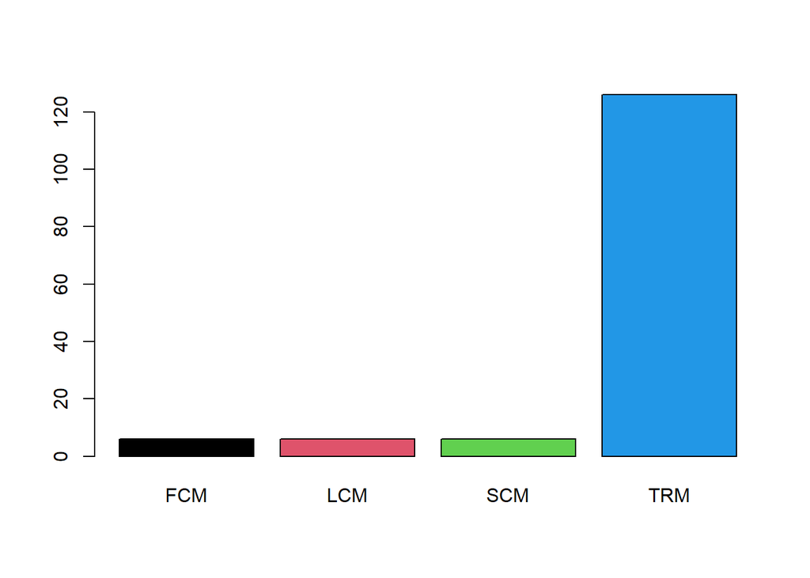

```r
barplot(sp,beside=TRUE,col=1:4)
```

A table of the rivers crossed with the fish species followed by a bar graph of the same data.

```r
spish=with(ddt,table(RIVER,SPECIES))
spish
```

```
##      SPECIES
## RIVER CCATFISH LMBASS SMBUFFALO
##   FCM        6      0         0
##   LCM        6      0         0
##   SCM        6      0         0
##   TRM       78     12        36
```

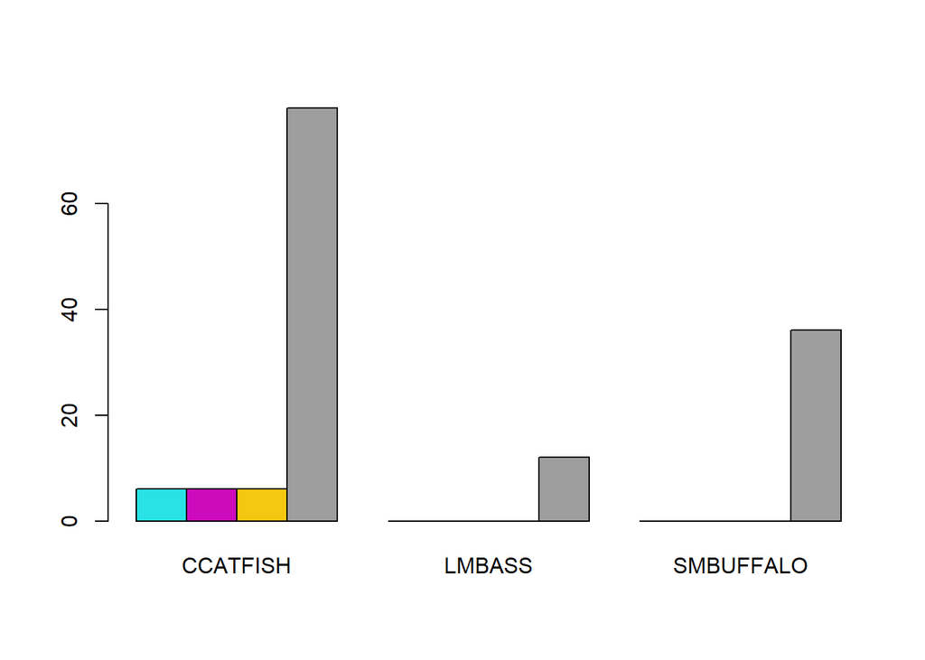

```r
barplot(spish,beside=TRUE,col=5:8)
```

## Task 5

A pie chart displaying the Species of fish.

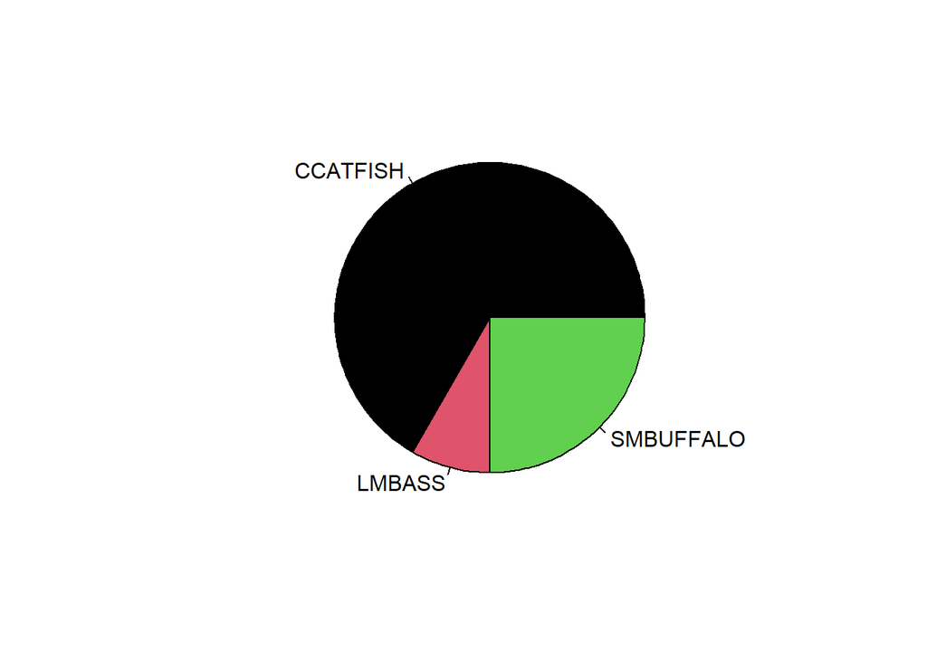

```r
spec=with(ddt,table(SPECIES))
pie(spec, col = 9:11)
```

A pie chart of the Rivers fish were found.

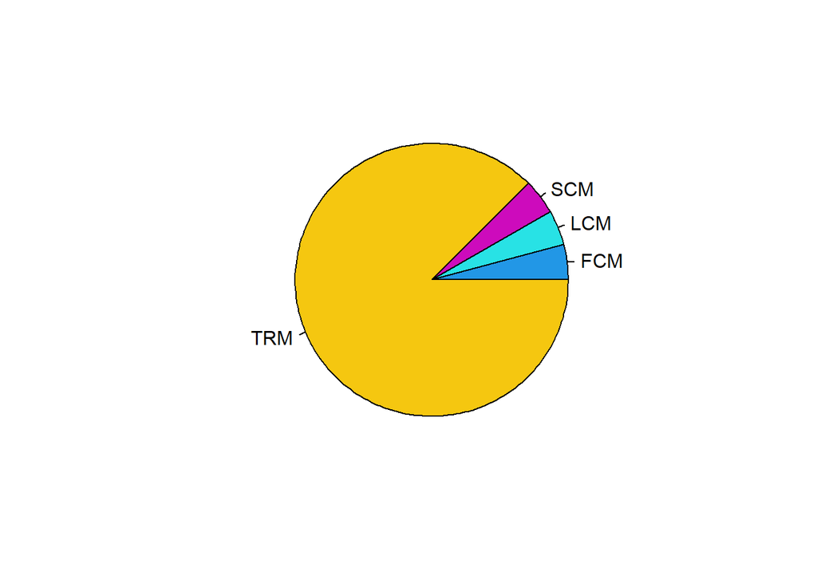

```r
riv=with(ddt,table(RIVER))
pie(riv, col = 12:15)
```

## Task 6

Box plot of the DDT data.

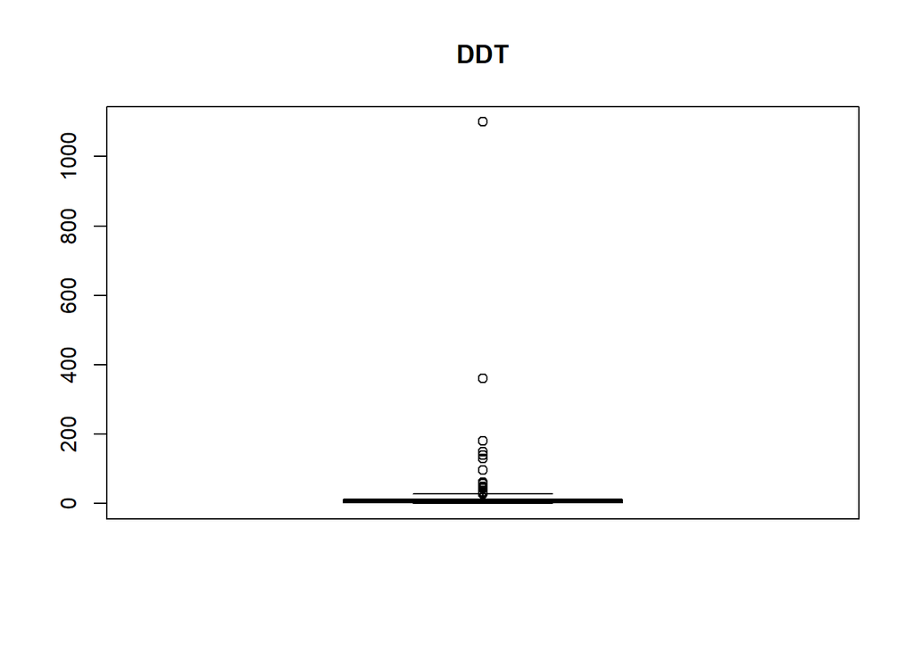

```r
boxplot(ddt$DDT, col="Green", main="DDT")
```

Box plot of the fish Weight.

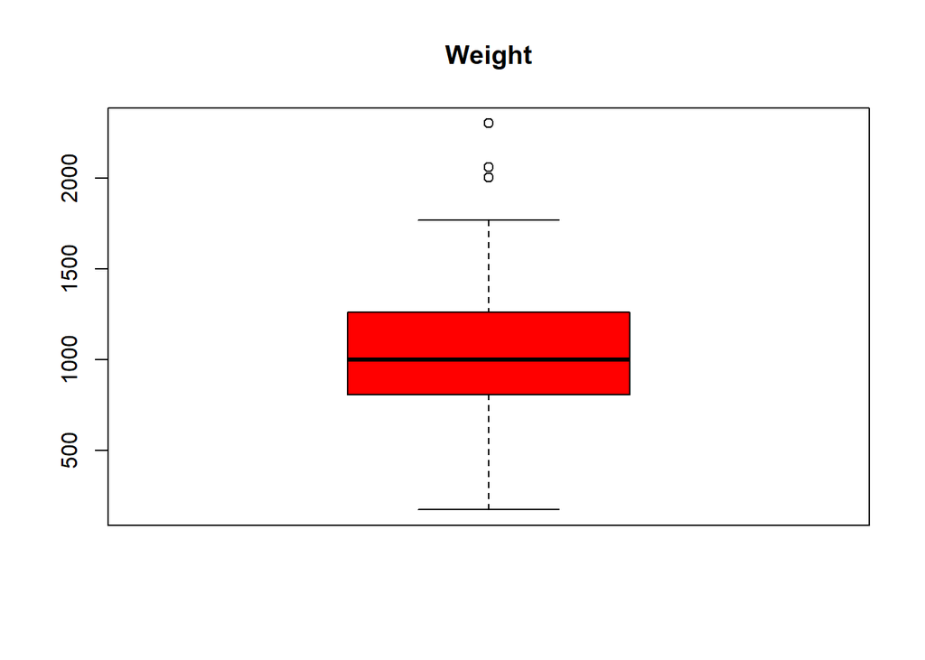

```r
boxplot(ddt$WEIGHT, col="RED", main="Weight")
```

Box plot of the fish Length.

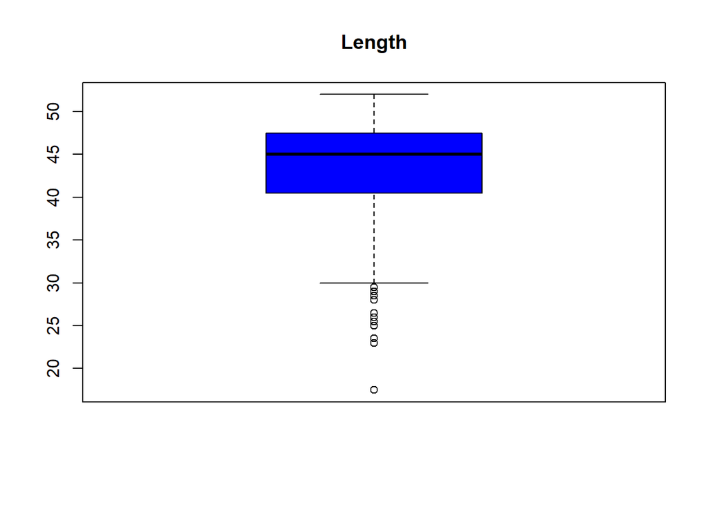

```r
boxplot(ddt$LENGTH, col="BLUE", main="Length")
```

## Task 7

Co-plot comparing the Length vs. Weight of the fish by their River.

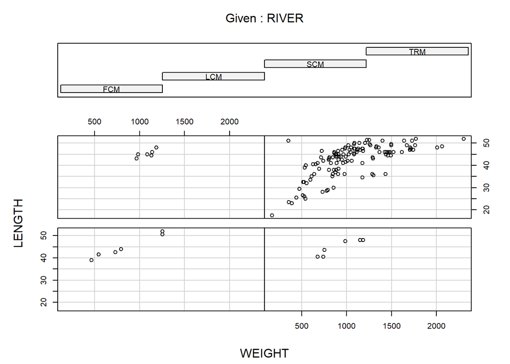

```r
with(ddt, coplot(LENGTH~WEIGHT|RIVER))
```

Co-plot comparing the DDT vs. Weight of the fish by their Species.

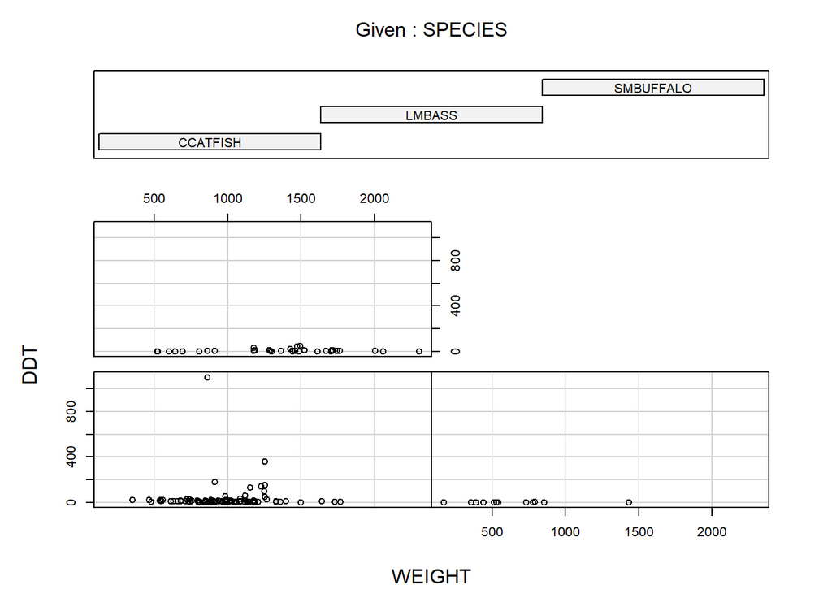

```r
with(ddt, coplot(DDT~WEIGHT|SPECIES))
```

## Task 8

Box plot of the Species vs. Weight catagorized by their River.

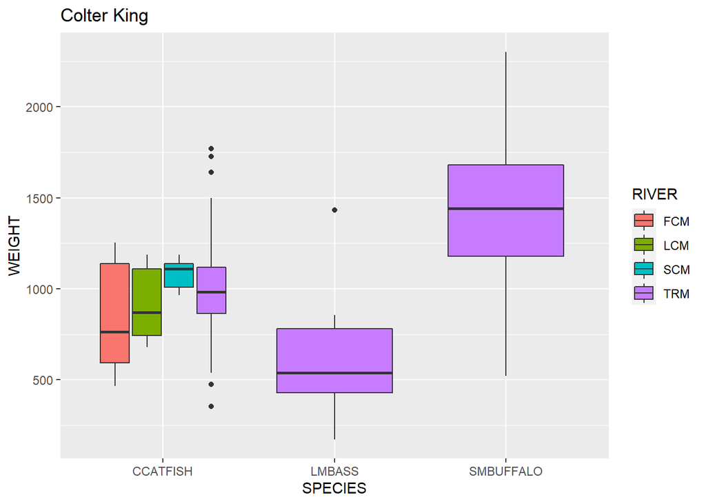

```r
library(ggplot2)
g = ggplot(ddt, aes(x=SPECIES , y=WEIGHT, fill=RIVER))
g = g + geom_boxplot() + ggtitle("Colter King")
g
```

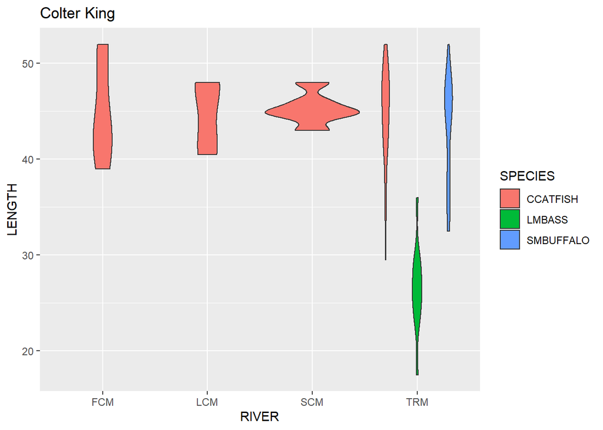

```r
h = ggplot(ddt, aes(x=RIVER , y=LENGTH, fill=SPECIES))
h = h + geom_violin() + ggtitle("Colter King")
h
```

Point plot of the Weight vs. Length of fish catagorized by their species.

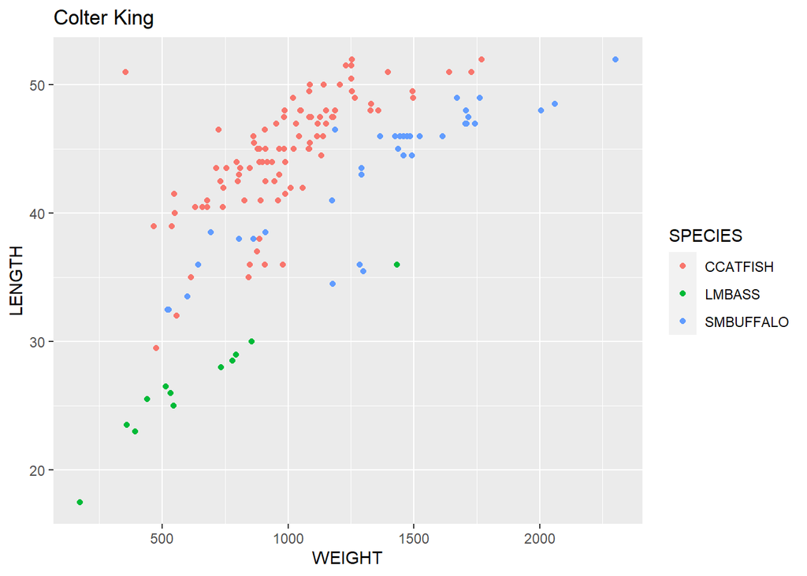

```r
h = ggplot(ddt, aes(x=WEIGHT , y=LENGTH, fill=SPECIES, color = SPECIES))
h = h + geom_point() + ggtitle("Colter King")
h
```